# Exercício: SARIMA no comércio varejista brasileiro — São Paulo

Autor

Nicole Cristine

## Sobre o exercício

A base é a **PMC** (Pesquisa Mensal do Comércio) do IBGE: índice de volume de vendas no **comércio varejista ampliado** (inclui veículos e materiais de construção), por **Unidade da Federação**, mensal de jan/2004 em diante. Base 2022 = 100, **sem ajuste sazonal**.

UF de interesse: **São Paulo**.

## Setup

**Código**

```python
import numpy as np
import pandas as pd
import matplotlib.pyplot as plt

from statsmodels.tsa.stattools import adfuller, kpss
from statsmodels.graphics.tsaplots import plot_acf, plot_pacf
from statsmodels.tsa.seasonal import seasonal_decompose
from statsmodels.stats.diagnostic import acorr_ljungbox

from statsforecast import StatsForecast
from statsforecast.models import AutoARIMA, ARIMA
from statsforecast.arima import ndiffs, nsdiffs

import warnings
warnings.filterwarnings('ignore')

plt.style.use('default')
plt.rcParams.update({
    'figure.facecolor':'#FFFFFF','axes.facecolor':'#F9F9F9',
    'axes.edgecolor':'#BBBBBB','axes.labelcolor':'#1C1C1C',
    'xtick.color':'#444444','ytick.color':'#444444',
    'text.color':'#1C1C1C','grid.color': '#DDDDDD',
    'grid.linestyle':'--','grid.alpha':0.5,'figure.dpi':110,
})
RED,BLUE,GREEN,GRAY,YELLOW='#E4002B','#1a6fc4','#1a9b57','#555555','#cc8800'
```

## Carregando a base PMC

A base já foi pré-processada para conter apenas as colunas relevantes, e já no formato “long” (uma linha por data + UF). O nome da coluna de data é “data”, e a coluna de interesse (índice de volume) é “volume_idx”. A coluna “uf” indica a Unidade da Federação.

**Código**

```python
pmc = pd.read_csv("https://github.com/padsInsper/202634-fa/releases/download/data/pmc_volume_uf.csv")
pmc.head()
```

|  | uf | data | volume_idx |
| --- | --- | --- | --- |
| 0 | Acre | 2004-01-01 | 18.16706 |
| 1 | Acre | 2004-02-01 | 17.24721 |
| 2 | Acre | 2004-03-01 | 20.77331 |
| 3 | Acre | 2004-04-01 | 19.24022 |
| 4 | Acre | 2004-05-01 | 21.46320 |

## Escolha sua UF

**Código**

```python
MINHA_UF = "São Paulo"

df_sf = (
    pmc.query("uf == @MINHA_UF")
    .rename(columns={"uf": "unique_id", "data": "ds", "volume_idx": "y"})
    [["unique_id", "ds", "y"]]
    .reset_index(drop=True)
)
df_sf['ds'] = pd.to_datetime(df_sf['ds'])

# Versão indexada por data (mesmo formato do `ibc` usado em aula)
pmc_sp = df_sf.set_index('ds')[['y']].asfreq('MS')

print(f"✅ PMC {MINHA_UF} carregada!")
print(f"   Período: {pmc_sp.index[0].date()} → {pmc_sp.index[-1].date()}")
print(f"   Observações: {len(pmc_sp)}")
df_sf.head()
```

```
✅ PMC São Paulo carregada!
   Período: 2004-01-01 → 2026-02-01
   Observações: 266
```

|  | unique_id | ds | y |
| --- | --- | --- | --- |
| 0 | São Paulo | 2004-01-01 | 52.53519 |
| 1 | São Paulo | 2004-02-01 | 50.98433 |
| 2 | São Paulo | 2004-03-01 | 57.18775 |
| 3 | São Paulo | 2004-04-01 | 54.76454 |
| 4 | São Paulo | 2004-05-01 | 57.09082 |

## Análise descritiva

### Série em nível e ACF

**Código**

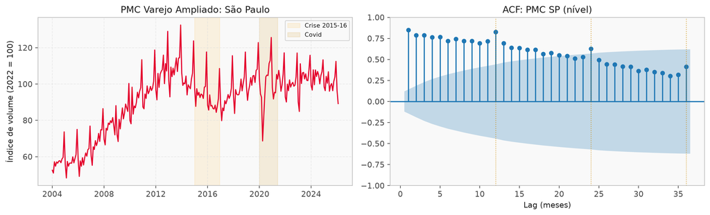

```
💡 ACF decai lentamente → não-estacionária (tendência)
💡 Picos nos lags 12, 24, 36 → sazonalidade anual
```

```python
fig, axes = plt.subplots(1, 2, figsize=(13, 4))

axes[0].plot(pmc_sp.index, pmc_sp['y'], color=RED, lw=1.4)
axes[0].set_title(f'PMC Varejo Ampliado: {MINHA_UF}')
axes[0].set_ylabel('Índice de volume (2022 = 100)'); axes[0].grid(True)
axes[0].axvspan(pd.Timestamp('2015-01-01'), pd.Timestamp('2016-12-01'),
                alpha=0.1, color='orange', label='Crise 2015-16')
axes[0].axvspan(pd.Timestamp('2020-01-01'), pd.Timestamp('2021-06-01'),
                alpha=0.12, color=YELLOW, label='Covid')
axes[0].legend(fontsize=8)

plot_acf(pmc_sp['y'], ax=axes[1], lags=36, zero=False, title='ACF: PMC SP (nível)')
axes[1].set_xlabel('Lag (meses)')
for lag in [12, 24, 36]:
    axes[1].axvline(lag, color=YELLOW, lw=1, ls=':', alpha=0.7)

plt.tight_layout(); plt.show()
print("💡 ACF decai lentamente → não-estacionária (tendência)")
print("💡 Picos nos lags 12, 24, 36 → sazonalidade anual")
```

### PACF em nível

**Código**

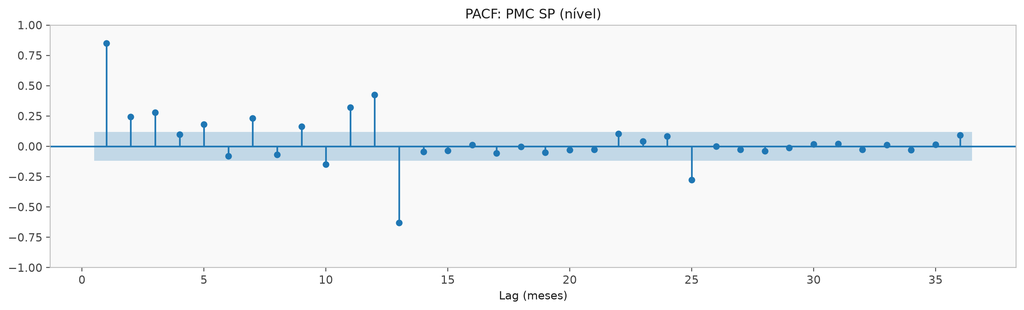

```
💡 PACF com lag 1 alto (≈0,85) e lag 12/13 relevantes → persistência + sazonalidade
```

```python
fig, ax = plt.subplots(figsize=(13, 4))
plot_pacf(pmc_sp['y'], ax=ax, lags=36, zero=False, title='PACF: PMC SP (nível)')
ax.set_xlabel('Lag (meses)')
plt.tight_layout(); plt.show()
print("💡 PACF com lag 1 alto (≈0,85) e lag 12/13 relevantes → persistência + sazonalidade")
```

### Decomposição aditiva

**Código**

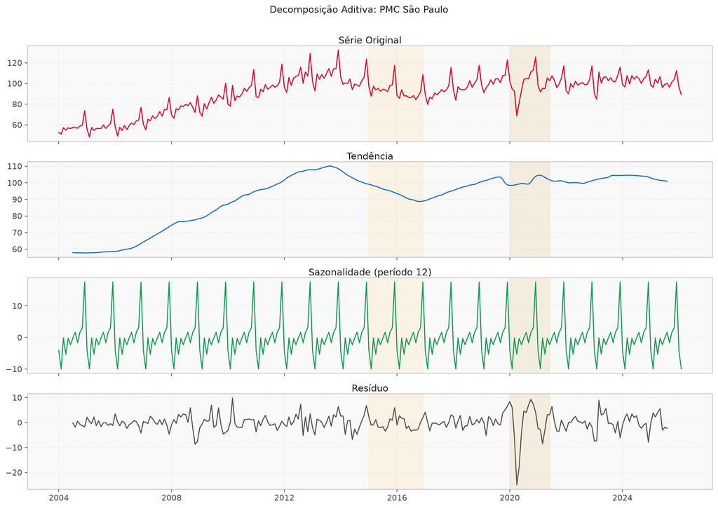

```
💡 Crise 2015-16 → tendência | Pico de dezembro → sazonalidade | Covid → resíduo
```

```python
decomp = seasonal_decompose(pmc_sp['y'], model='additive', period=12)

fig, axes = plt.subplots(4, 1, figsize=(13, 9), sharex=True)
for ax, (comp, color, label) in zip(axes, [
    (decomp.observed,  RED,   'Série Original'),
    (decomp.trend,     BLUE,  'Tendência'),
    (decomp.seasonal,  GREEN, 'Sazonalidade (período 12)'),
    (decomp.resid,     GRAY,  'Resíduo'),
]):
    ax.plot(comp, color=color, lw=1.3)
    ax.set_title(label, pad=2); ax.grid(True)
    ax.axvspan(pd.Timestamp('2015-01-01'), pd.Timestamp('2016-12-01'),
               alpha=0.08, color='orange')
    ax.axvspan(pd.Timestamp('2020-01-01'), pd.Timestamp('2021-06-01'),
               alpha=0.1, color=YELLOW)
fig.suptitle(f'Decomposição Aditiva: PMC {MINHA_UF}', fontsize=12, y=1.01)
plt.tight_layout(); plt.show()
print("💡 Crise 2015-16 → tendência | Pico de dezembro → sazonalidade | Covid → resíduo")
```

### Diferenciação

**Código**

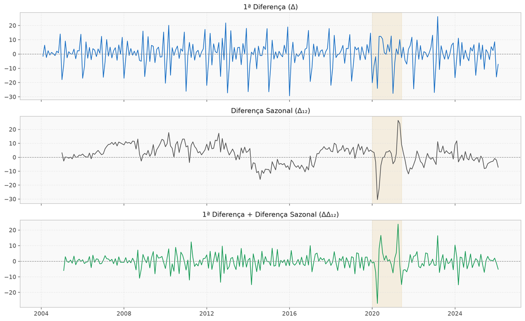

```python
# Defasagem, 1ª diferença e diferença sazonal
pmc_sp['y_lag1']      = pmc_sp['y'].shift(1)
pmc_sp['y_diff']      = pmc_sp['y'].diff(1)
pmc_sp['y_diff12']    = pmc_sp['y'].diff(12)
pmc_sp['y_diff_seas'] = pmc_sp['y_diff'].diff(12)

fig, axes = plt.subplots(3, 1, figsize=(13, 8), sharex=True)
for ax, (col, color, label) in zip(axes, [
    ('y_diff',      BLUE,  '1ª Diferença (Δ)'),
    ('y_diff12',    GRAY,  'Diferença Sazonal (Δ₁₂)'),
    ('y_diff_seas', GREEN, '1ª Diferença + Diferença Sazonal (ΔΔ₁₂)'),
]):
    ax.plot(pmc_sp.index, pmc_sp[col], color=color, lw=1.2)
    ax.axhline(0, color='#888', lw=0.8, ls='--')
    ax.set_title(label); ax.grid(True)
    ax.axvspan(pd.Timestamp('2020-01-01'), pd.Timestamp('2021-06-01'),
               alpha=0.1, color=YELLOW)
plt.tight_layout(); plt.show()
```

### ACF/PACF das séries diferenciadas

**Código**

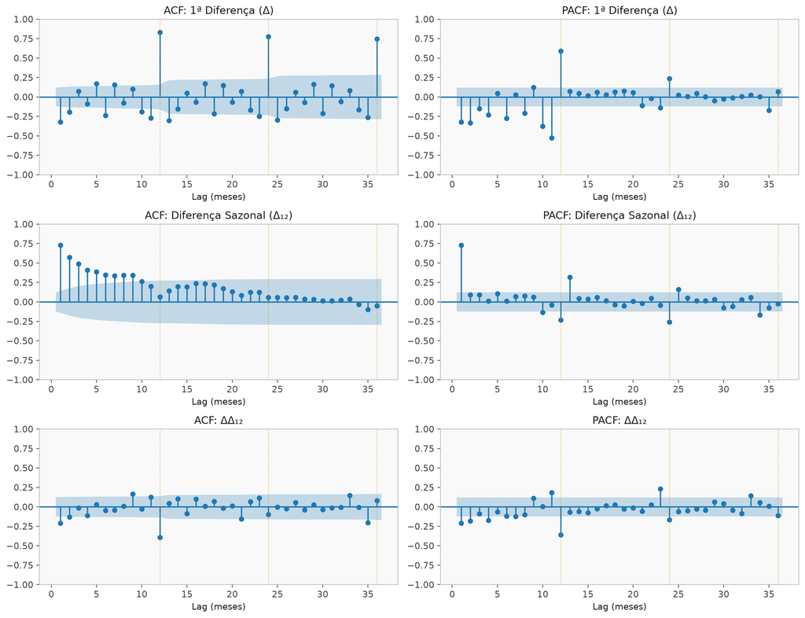

```
💡 Só Δ: picos fortes nos lags 12/24/36 → sazonalidade remanescente → precisa de diff(12)
💡 Só Δ₁₂: ACF ainda decai devagar → tendência remanescente → precisa de diff(1)
💡 ΔΔ₁₂: pico negativo no lag 12 → sugere SMA(1), Q=1
```

```python
fig, axes = plt.subplots(3, 2, figsize=(13, 10))

for row, (col, nome) in enumerate([
    ('y_diff',      '1ª Diferença (Δ)'),
    ('y_diff12',    'Diferença Sazonal (Δ₁₂)'),
    ('y_diff_seas', 'ΔΔ₁₂'),
]):
    plot_acf( pmc_sp[col].dropna(), ax=axes[row, 0], lags=36, zero=False, title=f'ACF: {nome}')
    plot_pacf(pmc_sp[col].dropna(), ax=axes[row, 1], lags=36, zero=False, title=f'PACF: {nome}')
    for ax in axes[row]:
        ax.set_xlabel('Lag (meses)')
        for lag in [12, 24, 36]:
            ax.axvline(lag, color=YELLOW, lw=1, ls=':', alpha=0.6)

plt.tight_layout(); plt.show()
print("💡 Só Δ: picos fortes nos lags 12/24/36 → sazonalidade remanescente → precisa de diff(12)")
print("💡 Só Δ₁₂: ACF ainda decai devagar → tendência remanescente → precisa de diff(1)")
print("💡 ΔΔ₁₂: pico negativo no lag 12 → sugere SMA(1), Q=1")
```

### Série estacionarizada + Dummy Covid

Mesmo procedimento da aula: retiramos os meses do choque da Covid (NaN) para ler a ACF/PACF sem a distorção do outlier.

**Código**

```
Meses com dummy Covid: ['Mar/2020', 'Apr/2020', 'May/2020', 'Jun/2020', 'Jul/2020', 'Aug/2020']
```

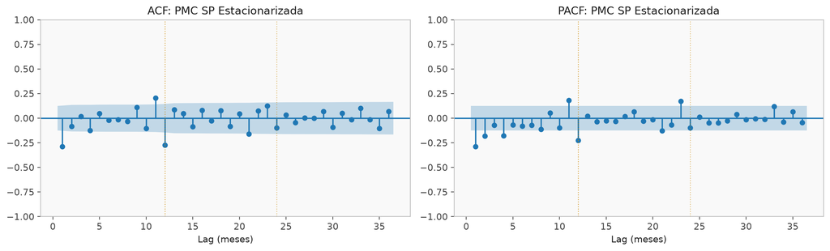

```
ACF lag 1  = -0.289 | ACF lag 12 = -0.272 | IC = ±0.125
```

```python
# Dummy Covid: mar/2020 a ago/2020 como NaN
pmc_sp['y_est'] = pmc_sp['y_diff_seas']
covid_idx = pmc_sp.index[pmc_sp.index >= '2020-03-01'][:6]
pmc_sp.loc[covid_idx, 'y_est'] = np.nan
print(f"Meses com dummy Covid: {list(covid_idx.strftime('%b/%Y'))}")

serie_est = pmc_sp['y_est'].dropna()

fig, axes = plt.subplots(1, 2, figsize=(13, 4))
plot_acf( serie_est, ax=axes[0], lags=36, zero=False, title='ACF: PMC SP Estacionarizada')
plot_pacf(serie_est, ax=axes[1], lags=36, zero=False, title='PACF: PMC SP Estacionarizada')
for ax in axes:
    ax.set_xlabel('Lag (meses)')
    ax.axvline(12, color=YELLOW, lw=1, ls=':', alpha=0.7)
    ax.axvline(24, color=YELLOW, lw=1, ls=':', alpha=0.5)
plt.tight_layout(); plt.show()

from statsmodels.tsa.stattools import acf as acf_func
acf_vals = acf_func(serie_est, nlags=36)[1:]
ci = 1.96/np.sqrt(len(serie_est))
print(f"ACF lag 1  = {acf_vals[0]:.3f} | ACF lag 12 = {acf_vals[11]:.3f} | IC = ±{ci:.3f}")
```

## Testes de raiz unitária

### ADF

H₀: a série tem raiz unitária (não estacionária).

**Código**

```python
def rodar_adf(serie, nome):
    """Teste ADF com resultado formatado."""
    serie = serie.dropna()
    k = int(np.floor((len(serie) - 1) ** (1/3)))
    res = adfuller(serie, maxlag=k, autolag=None, regression='c')
    conclusao = "✅ Rejeita H₀ → ESTACIONÁRIA" if res[1] < 0.05 else "⚠️  Não rejeita H₀ → RAIZ UNITÁRIA"
    print(f"{'='*50}")
    print(f"ADF: {nome}")
    print(f"{'='*50}")
    print(f"  Estatística ADF : {res[0]:.4f}")
    print(f"  p-value         : {res[1]:.4f}")
    print(f"  Lags usados     : {res[2]}")
    print(f"  Valores críticos:")
    for nivel, valor in res[4].items():
        print(f"    {nivel}: {valor:.4f}")
    print(f"  → {conclusao}\n")
    return res[1]

p1 = rodar_adf(pmc_sp['y'],           'PMC SP, Nível')
p2 = rodar_adf(pmc_sp['y_diff'],      'PMC SP, 1ª Diferença')
p3 = rodar_adf(pmc_sp['y_diff12'],    'PMC SP, Diff Sazonal')
p4 = rodar_adf(pmc_sp['y_diff_seas'], 'PMC SP, Diff + Diff Sazonal')
```

```
==================================================
ADF: PMC SP, Nível
==================================================
  Estatística ADF : -2.1898
  p-value         : 0.2100
  Lags usados     : 6
  Valores críticos:
    1%: -3.4559
    5%: -2.8728
    10%: -2.5728
  → ⚠️  Não rejeita H₀ → RAIZ UNITÁRIA

==================================================
ADF: PMC SP, 1ª Diferença
==================================================
  Estatística ADF : -8.8314
  p-value         : 0.0000
  Lags usados     : 6
  Valores críticos:
    1%: -3.4560
    5%: -2.8728
    10%: -2.5728
  → ✅ Rejeita H₀ → ESTACIONÁRIA

==================================================
ADF: PMC SP, Diff Sazonal
==================================================
  Estatística ADF : -3.1182
  p-value         : 0.0252
  Lags usados     : 6
  Valores críticos:
    1%: -3.4571
    5%: -2.8733
    10%: -2.5730
  → ✅ Rejeita H₀ → ESTACIONÁRIA

==================================================
ADF: PMC SP, Diff + Diff Sazonal
==================================================
  Estatística ADF : -8.8935
  p-value         : 0.0000
  Lags usados     : 6
  Valores críticos:
    1%: -3.4572
    5%: -2.8734
    10%: -2.5731
  → ✅ Rejeita H₀ → ESTACIONÁRIA
```

### KPSS

H₀: a série é estacionária (hipótese invertida em relação ao ADF). O p-valor do KPSS é tabelado entre 0,01 e 0,10: valores nas bordas significam “≤ 0,01” ou “≥ 0,10”.

**Código**

```python
def rodar_kpss(serie, nome):
    """Teste KPSS com resultado formatado (mesmo formato do rodar_adf)."""
    serie = serie.dropna()
    res = kpss(serie, regression='c', nlags='auto')
    conclusao = "⚠️  Rejeita H₀ → NÃO ESTACIONÁRIA" if res[1] < 0.05 else "✅ Não rejeita H₀ → ESTACIONÁRIA"
    print(f"{'='*50}")
    print(f"KPSS: {nome}")
    print(f"{'='*50}")
    print(f"  Estatística KPSS: {res[0]:.4f}")
    print(f"  p-value         : {res[1]:.4f}")
    print(f"  Lags usados     : {res[2]}")
    print(f"  Valores críticos:")
    for nivel, valor in res[3].items():
        print(f"    {nivel}: {valor:.4f}")
    print(f"  → {conclusao}\n")
    return res[1]

k1 = rodar_kpss(pmc_sp['y'],           'PMC SP, Nível')
k2 = rodar_kpss(pmc_sp['y_diff'],      'PMC SP, 1ª Diferença')
k3 = rodar_kpss(pmc_sp['y_diff12'],    'PMC SP, Diff Sazonal')
k4 = rodar_kpss(pmc_sp['y_diff_seas'], 'PMC SP, Diff + Diff Sazonal')
```

```
==================================================
KPSS: PMC SP, Nível
==================================================
  Estatística KPSS: 1.6202
  p-value         : 0.0100
  Lags usados     : 10
  Valores críticos:
    10%: 0.3470
    5%: 0.4630
    2.5%: 0.5740
    1%: 0.7390
  → ⚠️  Rejeita H₀ → NÃO ESTACIONÁRIA

==================================================
KPSS: PMC SP, 1ª Diferença
==================================================
  Estatística KPSS: 0.2710
  p-value         : 0.1000
  Lags usados     : 32
  Valores críticos:
    10%: 0.3470
    5%: 0.4630
    2.5%: 0.5740
    1%: 0.7390
  → ✅ Não rejeita H₀ → ESTACIONÁRIA

==================================================
KPSS: PMC SP, Diff Sazonal
==================================================
  Estatística KPSS: 0.5244
  p-value         : 0.0362
  Lags usados     : 9
  Valores críticos:
    10%: 0.3470
    5%: 0.4630
    2.5%: 0.5740
    1%: 0.7390
  → ⚠️  Rejeita H₀ → NÃO ESTACIONÁRIA

==================================================
KPSS: PMC SP, Diff + Diff Sazonal
==================================================
  Estatística KPSS: 0.0550
  p-value         : 0.1000
  Lags usados     : 16
  Valores críticos:
    10%: 0.3470
    5%: 0.4630
    2.5%: 0.5740
    1%: 0.7390
  → ✅ Não rejeita H₀ → ESTACIONÁRIA
```

### Resumo e `ndiffs`

**Código**

```python
resumo = pd.DataFrame({
    'Série':        ['Nível', 'Δ', 'Δ₁₂', 'ΔΔ₁₂'],
    'ADF p-value':  [p1, p2, p3, p4],
    'KPSS p-value': [k1, k2, k3, k4],
})
resumo['Estacionária?'] = np.where((resumo['ADF p-value'] < 0.05) & (resumo['KPSS p-value'] > 0.05),
                                   '✅ Sim', '⚠️ Não')
print(resumo.round(4).to_string(index=False))

n_d = ndiffs(pmc_sp['y'].values)              # diferenças regulares (teste KPSS)
n_D = nsdiffs(pmc_sp['y'].values, period=12)  # diferenças sazonais
print(f"\nndiffs  → d = {n_d} diferença(s) regular(es)")
print(f"nsdiffs → D = {n_D} diferença(s) sazonal(is)")
```

```
Série  ADF p-value  KPSS p-value Estacionária?
Nível       0.2100        0.0100        ⚠️ Não
    Δ       0.0000        0.1000         ✅ Sim
  Δ₁₂       0.0252        0.0362        ⚠️ Não
 ΔΔ₁₂       0.0000        0.1000         ✅ Sim

ndiffs  → d = 1 diferença(s) regular(es)
nsdiffs → D = 1 diferença(s) sazonal(is)
```

## Modelagem

**Código**

```python
sf = StatsForecast(
    models=[AutoARIMA(season_length=12)],
    freq='MS',
    n_jobs=1,
)
sf.fit(df=df_sf)

# Inspecionar modelo selecionado
modelo = sf.fitted_[0, 0].model_
arma   = modelo['arma']  # [p, q, P, Q, s, d, D]
p, q, P, Q, s, d, D = arma
print(f"✅ Modelo selecionado: SARIMA({p},{d},{q})({P},{D},{Q})[{s}]")
print(f"   AIC  : {modelo['aic']:.3f}")
print(f"   AICc : {modelo['aicc']:.3f}")
print(f"   BIC  : {modelo['bic']:.3f}")
print(f"   sigma: {modelo['sigma2']**0.5:.4f}")
print("\nCoeficientes:")
for nome, valor in modelo['coef'].items():
    print(f"   {nome:>5}: {valor:.4f}")
```

```
✅ Modelo selecionado: SARIMA(2,1,1)(0,1,1)[12]
   AIC  : 1446.300
   AICc : 1446.543
   BIC  : 1463.967
   sigma: 4.0354

Coeficientes:
     ar1: 0.5066
     ar2: 0.0019
     ma1: -0.8020
    sma1: -0.8586
```

## Diagnóstico dos resíduos

**Código**

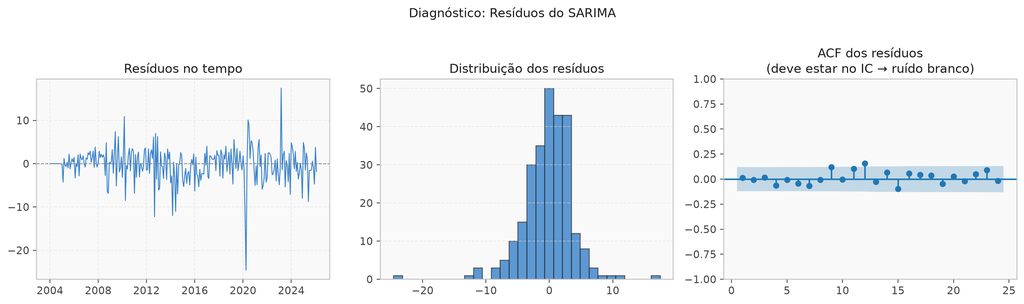

```
Teste Ljung-Box (H₀: resíduos são ruído branco)
    lb_stat  lb_pvalue
12  16.7676     0.1586
24  26.6302     0.3220
✅ Resíduos são ruído branco!

Maior resíduo: Apr/2020 (-24.6)
```

```python
residuos = pd.Series(modelo.get('residuals', []), index=pmc_sp.index)

fig, axes = plt.subplots(1, 3, figsize=(14, 4))
axes[0].plot(residuos.index, residuos.values, color=BLUE, lw=0.9, alpha=0.85)
axes[0].axhline(0, color='#888', ls='--', lw=0.8)
axes[0].set_title('Resíduos no tempo'); axes[0].grid(True)
axes[1].hist(residuos, bins=30, color=BLUE, alpha=0.7, edgecolor='#333')
axes[1].set_title('Distribuição dos resíduos'); axes[1].grid(True, axis='y')
plot_acf(residuos, ax=axes[2], lags=24, zero=False,
         title='ACF dos resíduos\n(deve estar no IC → ruído branco)')
plt.suptitle('Diagnóstico: Resíduos do SARIMA', fontsize=12, y=1.02)
plt.tight_layout(); plt.show()

lb = acorr_ljungbox(residuos, lags=[12, 24], return_df=True)
print("Teste Ljung-Box (H₀: resíduos são ruído branco)")
print(lb.round(4))
pval = lb['lb_pvalue'].values[-1]
print("✅ Resíduos são ruído branco!" if pval > 0.05 else "⚠️  Revisar modelo")
print(f"\nMaior resíduo: {residuos.abs().idxmax():%b/%Y} ({residuos.loc[residuos.abs().idxmax()]:.1f})")
```

## Previsão · 24 meses à frente

**Código**

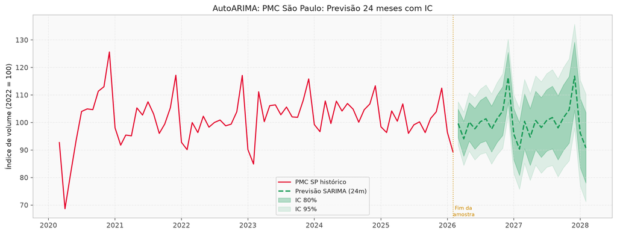

```
Amplitude do IC 95%: 15.8 pontos (h=1) → 39.1 pontos (h=24)
```

```python
# Previsão 24 meses com IC 80% e 95%
previsao = sf.predict(h=24, level=[80, 95])

fig, ax = plt.subplots(figsize=(13, 5))
# Histórico (últimos 6 anos)
hist = pmc_sp['y'].iloc[-72:]
ax.plot(hist.index, hist.values, color=RED, lw=1.6, label='PMC SP histórico')
ax.plot(previsao['ds'], previsao['AutoARIMA'],
        color=GREEN, lw=2, ls='--', label='Previsão SARIMA (24m)')
ax.fill_between(previsao['ds'],
    previsao['AutoARIMA-lo-80'], previsao['AutoARIMA-hi-80'],
    color=GREEN, alpha=0.30, label='IC 80%')
ax.fill_between(previsao['ds'],
    previsao['AutoARIMA-lo-95'], previsao['AutoARIMA-hi-95'],
    color=GREEN, alpha=0.12, label='IC 95%')
ax.axvline(pmc_sp.index[-1], color=YELLOW, lw=1.2, ls=':', alpha=0.8)
ax.text(pmc_sp.index[-1], ax.get_ylim()[0], ' Fim da\namostra',
        color=YELLOW, fontsize=8, va='bottom')
ax.set_title(f'AutoARIMA: PMC {MINHA_UF}: Previsão 24 meses com IC')
ax.set_ylabel('Índice de volume (2022 = 100)')
ax.legend(fontsize=9); ax.grid(True)
plt.tight_layout(); plt.show()

amp = previsao['AutoARIMA-hi-95'] - previsao['AutoARIMA-lo-95']
print(f"Amplitude do IC 95%: {amp.iloc[0]:.1f} pontos (h=1) → {amp.iloc[-1]:.1f} pontos (h=24)")
```

**Código**

```python
previsao.round(2)
```

|  | unique_id | ds | AutoARIMA | AutoARIMA-lo-95 | AutoARIMA-lo-80 | AutoARIMA-hi-80 | AutoARIMA-hi-95 |
| --- | --- | --- | --- | --- | --- | --- | --- |
| 0 | São Paulo | 2026-03-01 | 99.64 | 91.73 | 94.47 | 104.81 | 107.55 |
| 1 | São Paulo | 2026-04-01 | 94.09 | 84.41 | 87.76 | 100.42 | 103.77 |
| 2 | São Paulo | 2026-05-01 | 100.23 | 89.59 | 93.27 | 107.18 | 110.86 |
| 3 | São Paulo | 2026-06-01 | 97.71 | 86.42 | 90.33 | 105.10 | 109.01 |
| 4 | São Paulo | 2026-07-01 | 100.29 | 88.46 | 92.56 | 108.02 | 112.11 |
| 5 | São Paulo | 2026-08-01 | 101.35 | 89.06 | 93.32 | 109.39 | 113.64 |
| 6 | São Paulo | 2026-09-01 | 97.62 | 84.91 | 89.31 | 105.94 | 110.34 |
| 7 | São Paulo | 2026-10-01 | 101.34 | 88.22 | 92.76 | 109.92 | 114.46 |
| 8 | São Paulo | 2026-11-01 | 104.16 | 90.66 | 95.33 | 113.00 | 117.67 |
| 9 | São Paulo | 2026-12-01 | 116.40 | 102.52 | 107.33 | 125.48 | 130.28 |
| 10 | São Paulo | 2027-01-01 | 95.73 | 81.48 | 86.41 | 105.04 | 109.97 |
| 11 | São Paulo | 2027-02-01 | 90.35 | 75.75 | 80.80 | 99.89 | 104.94 |
| 12 | São Paulo | 2027-03-01 | 100.42 | 85.20 | 90.47 | 110.37 | 115.64 |
| 13 | São Paulo | 2027-04-01 | 94.70 | 78.97 | 84.42 | 104.99 | 110.43 |
| 14 | São Paulo | 2027-05-01 | 100.76 | 84.57 | 90.18 | 111.34 | 116.94 |
| 15 | São Paulo | 2027-06-01 | 98.20 | 81.59 | 87.34 | 109.06 | 114.81 |
| 16 | São Paulo | 2027-07-01 | 100.76 | 83.74 | 89.63 | 111.88 | 117.77 |
| 17 | São Paulo | 2027-08-01 | 101.81 | 84.41 | 90.43 | 113.19 | 119.21 |
| 18 | São Paulo | 2027-09-01 | 98.07 | 80.29 | 86.45 | 109.70 | 115.85 |
| 19 | São Paulo | 2027-10-01 | 101.79 | 83.64 | 89.92 | 113.65 | 119.94 |
| 20 | São Paulo | 2027-11-01 | 104.61 | 86.10 | 92.51 | 116.71 | 123.12 |
| 21 | São Paulo | 2027-12-01 | 116.85 | 97.98 | 104.51 | 129.18 | 135.71 |
| 22 | São Paulo | 2028-01-01 | 96.17 | 76.96 | 83.61 | 108.73 | 115.38 |
| 23 | São Paulo | 2028-02-01 | 90.79 | 71.24 | 78.01 | 103.58 | 110.35 |

## Discussão

**1. O ACF/PACF da série original sugeriu sazonalidade? E tendência? Bate com o gráfico de linha?** Sim para as duas. A ACF em nível decai devagar (0,85 no lag 1, ainda 0,41 no lag 36), sinal de **tendência**/raiz unitária, e tem “ondas” com picos nos lags 12, 24 e 36, sinal de **sazonalidade anual**. Bate com o gráfico de linha: alta até 2014, queda na crise de 2015–16, recuperação, e picos todo dezembro (Natal) com vale em fevereiro.

**2. Quantas diferenças o AutoARIMA aplicou? E os componentes AR/MA? Deu para ver no ACF/PACF?** O AutoARIMA escolheu **SARIMA(2,1,1)(0,1,1)[12]**: **d = 1** e **D = 1**, as mesmas que `ndiffs`/`nsdiffs` sugeriram e que os testes confirmaram. Só ΔΔ₁₂ (assim como Δ) passa no ADF *e* no KPSS; com só Δ₁₂ os testes discordam. Na ACF de ΔΔ₁₂, o pico negativo no lag 12 (≈ −0,39) indica o **SMA(1)** (`sma1` = −0,86), e o pico negativo no lag 1 indica o **MA(1)** (`ma1` = −0,80). O AR(2) é mais difícil de ver a olho, já que AR e MA juntos geram padrões que se misturam. Na prática, o `ar2` ≈ 0, então a parte regular funciona como um ARMA(1,1).

**4. A previsão pareceu razoável?** Sim. Ela captura bem a sazonalidade (pico em dezembro, vale em fevereiro), fica ancorada no nível recente (~100) e segue quase estável, com leve alta. Os intervalos **abrem bastante** com o horizonte (IC 95% vai de ~16 pontos em h = 1 para ~39 pontos em h = 24). Isso é esperado num modelo com d = 1 e D = 1, em que a incerteza se acumula a cada passo.

**5. Que outras UFs dariam um SARIMA bem diferente?** São Paulo é uma economia grande e diversificada, com sazonalidade “de livro”. Esperaria modelos diferentes em:

- **UFs pequenas do Norte** (Roraima, Amapá, Acre): séries mais ruidosas e com tendência de crescimento mais forte (migração, obras públicas), possivelmente com mais termos AR/MA.
- **Estados do agro** (Mato Grosso, Goiás): o varejo ampliado (veículos e materiais de construção) acompanha a safra e a renda agrícola, mudando o formato da sazonalidade.
- **Estados turísticos do Nordeste**: picos também em julho e no verão, o que pode exigir outra estrutura sazonal (P > 0).